# Topic 1 Exercises

## 2.4.2

2a) This is a regression problem. We are interested in inference. $n=500$ and $p=4$.

2b) This is a classification problem and we are most interested in prediction. $n = 20$ and $p= 14$.

2c) This is a regression problem and we are most interested in prediction.

## 2.4.3

## (a) Graphs of Bias-Variance

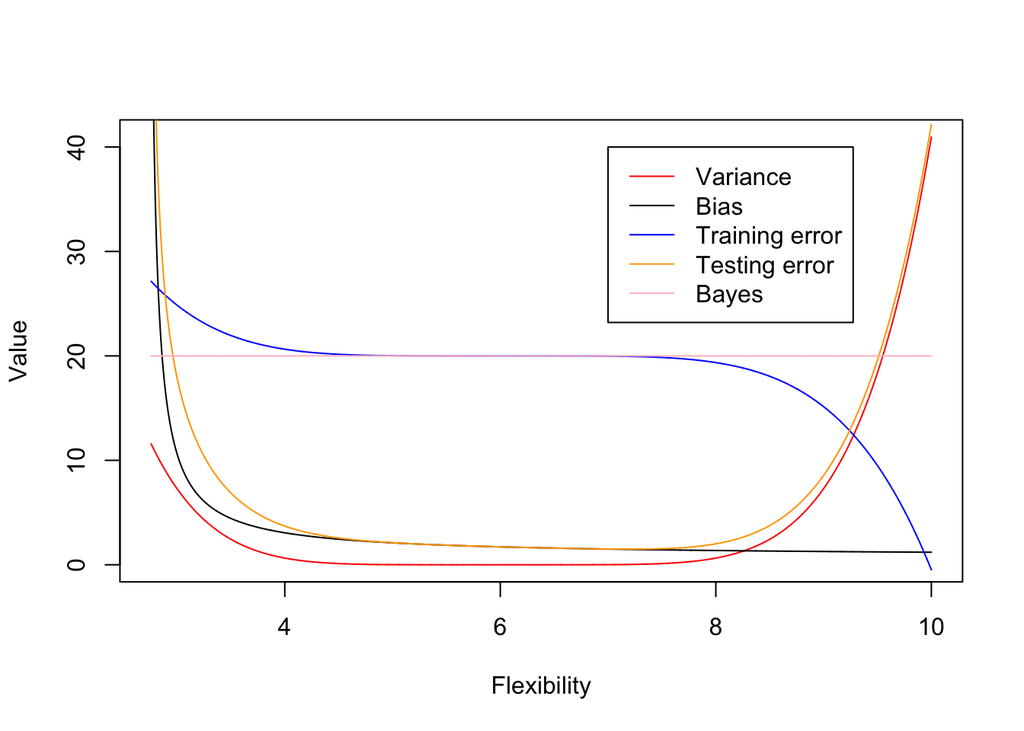

```r
bias=function(x){1/log(log(x))}
varf = function(x){(x-6)^6/100}
training_error=function(x){-(x-6)^5/50+20}
testing_error = function(x){varf(x)+bias(x)}
bayes=function(x){rep(20,length(x))}

xx=seq(2760,10000)/1000
plot(xx,xlab='Flexibility', ylab='Value',varf(xx),type='l',col='red')
lines(xx,bias(xx),type='l')
lines(xx,training_error(xx), col='blue')
lines(xx,testing_error(xx), col='orange')
lines(xx,bayes(xx), col='pink')

legend(7,40,c('Variance','Bias','Training error','Testing error','Bayes'),lty = 1,col=c('red','black','blue','orange','pink'))
```

## (b) Description of Curves

As we increase the flexibility, the bias decreases because $\hat{f}$ starts approximates the real world data and its non-linearities more closely.

The training error decreases as we increase flexibility. Increase flexibility of model allows the model to approximate the training data more closely and, invariably, capturing noise while doing so.

## 2.4.6

Parametric methods involve making assumptions about the functional form of $f$. Whereas non-parametric methods do not. Non parametric methods avoid deducing the incorrect functional form of f whereas parametric methods can. As a result of its flexible, non parametric methods can take on a variety of functional forms. However, non-parametric methods require a large amount of data to correctly determine $f$.

## 2.4.7

## (a) Compute euclidean distance between origin

Observation (1) - 3 Observation (2) - 2 Observation (3) - 10 Observation (4) - 5 Observation (5) - 2 Observation (6) - 3

I would expect the best K to be small since small K capture high variablity in data.

## 2.4.8 (a)

```r
college= read.csv("/Users/aarcher/Desktop/Maching Learning/College.csv")
```

## 2.4.8 (b)

```r
college=college[,-1]
fix(college)
```

## 2.4.8 (c) (i)

```r
summary(college)
```

```
##  Private        Apps           Accept          Enroll       Top10perc
##  No :212   Min.   :   81   Min.   :   72   Min.   :  35   Min.   : 1.00
##  Yes:565   1st Qu.:  776   1st Qu.:  604   1st Qu.: 242   1st Qu.:15.00
##            Median : 1558   Median : 1110   Median : 434   Median :23.00
##            Mean   : 3002   Mean   : 2019   Mean   : 780   Mean   :27.56
##            3rd Qu.: 3624   3rd Qu.: 2424   3rd Qu.: 902   3rd Qu.:35.00
##            Max.   :48094   Max.   :26330   Max.   :6392   Max.   :96.00
##    Top25perc      F.Undergrad     P.Undergrad         Outstate
##  Min.   :  9.0   Min.   :  139   Min.   :    1.0   Min.   : 2340
##  1st Qu.: 41.0   1st Qu.:  992   1st Qu.:   95.0   1st Qu.: 7320
##  Median : 54.0   Median : 1707   Median :  353.0   Median : 9990
##  Mean   : 55.8   Mean   : 3700   Mean   :  855.3   Mean   :10441
##  3rd Qu.: 69.0   3rd Qu.: 4005   3rd Qu.:  967.0   3rd Qu.:12925
##  Max.   :100.0   Max.   :31643   Max.   :21836.0   Max.   :21700
##    Room.Board       Books           Personal         PhD
##  Min.   :1780   Min.   :  96.0   Min.   : 250   Min.   :  8.00
##  1st Qu.:3597   1st Qu.: 470.0   1st Qu.: 850   1st Qu.: 62.00
##  Median :4200   Median : 500.0   Median :1200   Median : 75.00
##  Mean   :4358   Mean   : 549.4   Mean   :1341   Mean   : 72.66
##  3rd Qu.:5050   3rd Qu.: 600.0   3rd Qu.:1700   3rd Qu.: 85.00
##  Max.   :8124   Max.   :2340.0   Max.   :6800   Max.   :103.00
##     Terminal       S.F.Ratio      perc.alumni        Expend
##  Min.   : 24.0   Min.   : 2.50   Min.   : 0.00   Min.   : 3186
##  1st Qu.: 71.0   1st Qu.:11.50   1st Qu.:13.00   1st Qu.: 6751
##  Median : 82.0   Median :13.60   Median :21.00   Median : 8377
##  Mean   : 79.7   Mean   :14.09   Mean   :22.74   Mean   : 9660
##  3rd Qu.: 92.0   3rd Qu.:16.50   3rd Qu.:31.00   3rd Qu.:10830
##  Max.   :100.0   Max.   :39.80   Max.   :64.00   Max.   :56233
##    Grad.Rate
##  Min.   : 10.00
##  1st Qu.: 53.00
##  Median : 65.00
##  Mean   : 65.46
##  3rd Qu.: 78.00
##  Max.   :118.00
```

## 2.4.8 (c) (ii)

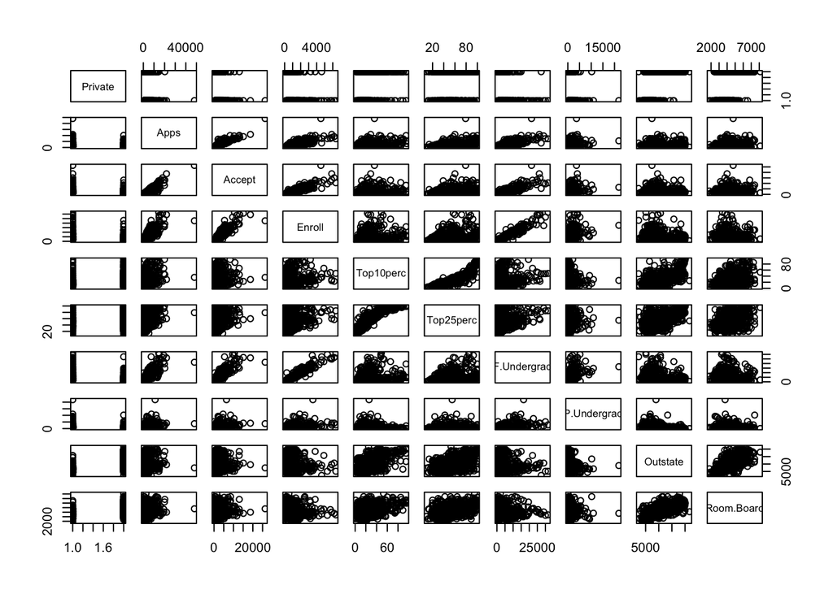

```r
pairs(college[,1:10])
```

## 2.4.8 (c) (iii)

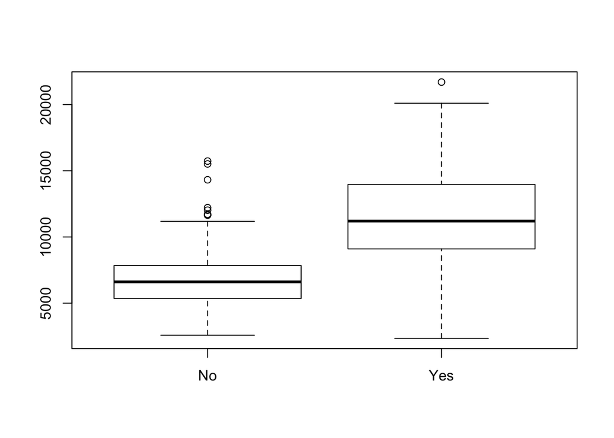

```r
plot(college$Private,college$Outstate)
```

## 2.4.8 (c) (iv)

```r
Elite=rep("No",nrow(college))
Elite[college$Top10perc >50]="Yes"
Elite=as.factor(Elite)
college=data.frame(college ,Elite)
```

```r
summary(college)
```

```
##  Private        Apps           Accept          Enroll       Top10perc
##  No :212   Min.   :   81   Min.   :   72   Min.   :  35   Min.   : 1.00
##  Yes:565   1st Qu.:  776   1st Qu.:  604   1st Qu.: 242   1st Qu.:15.00
##            Median : 1558   Median : 1110   Median : 434   Median :23.00
##            Mean   : 3002   Mean   : 2019   Mean   : 780   Mean   :27.56
##            3rd Qu.: 3624   3rd Qu.: 2424   3rd Qu.: 902   3rd Qu.:35.00
##            Max.   :48094   Max.   :26330   Max.   :6392   Max.   :96.00
##    Top25perc      F.Undergrad     P.Undergrad         Outstate
##  Min.   :  9.0   Min.   :  139   Min.   :    1.0   Min.   : 2340
##  1st Qu.: 41.0   1st Qu.:  992   1st Qu.:   95.0   1st Qu.: 7320
##  Median : 54.0   Median : 1707   Median :  353.0   Median : 9990
##  Mean   : 55.8   Mean   : 3700   Mean   :  855.3   Mean   :10441
##  3rd Qu.: 69.0   3rd Qu.: 4005   3rd Qu.:  967.0   3rd Qu.:12925
##  Max.   :100.0   Max.   :31643   Max.   :21836.0   Max.   :21700
##    Room.Board       Books           Personal         PhD
##  Min.   :1780   Min.   :  96.0   Min.   : 250   Min.   :  8.00
##  1st Qu.:3597   1st Qu.: 470.0   1st Qu.: 850   1st Qu.: 62.00
##  Median :4200   Median : 500.0   Median :1200   Median : 75.00
##  Mean   :4358   Mean   : 549.4   Mean   :1341   Mean   : 72.66
##  3rd Qu.:5050   3rd Qu.: 600.0   3rd Qu.:1700   3rd Qu.: 85.00
##  Max.   :8124   Max.   :2340.0   Max.   :6800   Max.   :103.00
##     Terminal       S.F.Ratio      perc.alumni        Expend
##  Min.   : 24.0   Min.   : 2.50   Min.   : 0.00   Min.   : 3186
##  1st Qu.: 71.0   1st Qu.:11.50   1st Qu.:13.00   1st Qu.: 6751
##  Median : 82.0   Median :13.60   Median :21.00   Median : 8377
##  Mean   : 79.7   Mean   :14.09   Mean   :22.74   Mean   : 9660
##  3rd Qu.: 92.0   3rd Qu.:16.50   3rd Qu.:31.00   3rd Qu.:10830
##  Max.   :100.0   Max.   :39.80   Max.   :64.00   Max.   :56233
##    Grad.Rate      Elite
##  Min.   : 10.00   No :699
##  1st Qu.: 53.00   Yes: 78
##  Median : 65.00
##  Mean   : 65.46
##  3rd Qu.: 78.00
##  Max.   :118.00
```

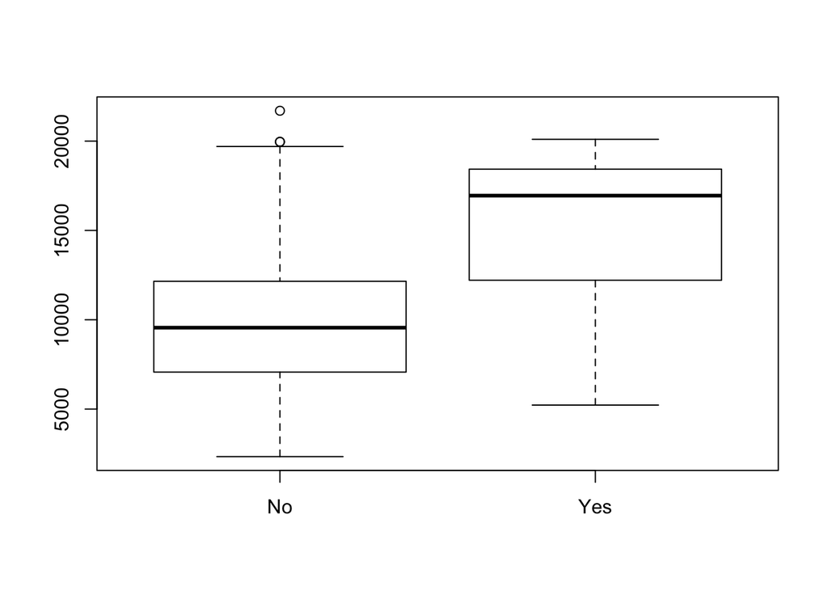

```r
plot(college$Elite,college$Outstate)
```

## 2.4.8 (c) (v)

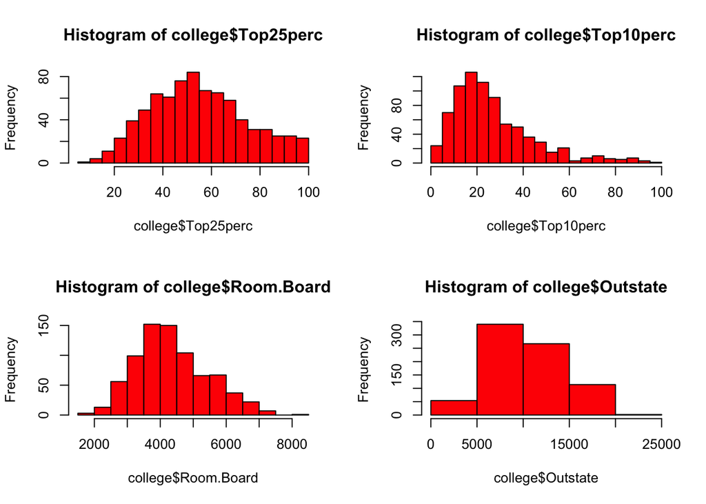

```r
par(mfrow=c(2,2))
hist(college$Top25perc,col=2,breaks=20)
hist(college$Top10perc,col=2,breaks=15)
hist(college$Room.Board,col=2,breaks=10)
hist(college$Outstate,col=2,breaks=5)
```

## 2.4.9 (a)

```r
auto_file_name= "/Users/aarcher/Desktop/Maching Learning/Math-253-Assignments/Auto.csv"
Auto<-read.csv(auto_file_name,header=T,na.strings ="?")
Auto=na.omit(Auto)
fix(Auto)
names(Auto)
```

```
## [1] "mpg"          "cylinders"    "displacement" "horsepower"
## [5] "weight"       "acceleration" "year"         "origin"
## [9] "name"
```

The quantitative variables are mpg, displacement, hoursepower, weight and acceleration. Cylinders, year and origin in the absolute sense is quantitative variable. The qualitative variable is name. Although cylinders, year and origin are represented as numerics, we can treat them as qualitative variables.

## 2.4.9 (b)

```r
range(Auto$mpg)
```

```
## [1]  9.0 46.6
```

```r
range(Auto$cylinders)
```

```
## [1] 3 8
```

```r
range(Auto$displacement)
```

```
## [1]  68 455
```

```r
range(Auto$horsepower)
```

```
## [1]  46 230
```

```r
range(Auto$weight)
```

```
## [1] 1613 5140
```

```r
range(Auto$acceleration)
```

```
## [1]  8.0 24.8
```

```r
range(Auto$year)
```

```
## [1] 70 82
```

```r
range(Auto$origin)
```

```
## [1] 1 3
```

Mpg: 9.0 - 46.6 Cylinders: 3-8 Displacement: 68 - 455 Horsepower: 46 - 230 Weight: 1613 - 5140 Acceleration: 8.0 - 24.8 Year: 70 - 82 Origin: 1-3

## 2.4.9 (c)

```r
mean(Auto$mpg)
```

```
## [1] 23.44592
```

```r
mean(Auto$cylinders)
```

```
## [1] 5.471939
```

```r
mean(Auto$displacement)
```

```
## [1] 194.412
```

```r
mean(Auto$horsepower)
```

```
## [1] 104.4694
```

```r
mean(Auto$weight)
```

```
## [1] 2977.584
```

```r
mean(Auto$acceleration)
```

```
## [1] 15.54133
```

```r
mean(Auto$year)
```

```
## [1] 75.97959
```

```r
mean(Auto$origin)
```

```
## [1] 1.576531
```

```r
sd(Auto$mpg)
```

```
## [1] 7.805007
```

```r
sd(Auto$cylinders)
```

```
## [1] 1.705783
```

```r
sd(Auto$displacement)
```

```
## [1] 104.644
```

```r
sd(Auto$horsepower)
```

```
## [1] 38.49116
```

```r
sd(Auto$weight)
```

```
## [1] 849.4026
```

```r
sd(Auto$acceleration)
```

```
## [1] 2.758864
```

```r
sd(Auto$year)
```

```
## [1] 3.683737
```

```r
sd(Auto$origin)
```

```
## [1] 0.8055182
```

Mpg: mean - 23.4, sd - 7.8 Cylinders: mean - 5.47, sd - 1.70 Displacement: mean - 194.4, sd - 104.6 Horsepower: mean - 104.5, sd - 38.5 Weight: mean - 2977.6, sd - 849.4 Acceleration: mean: 15.54, sd - 2.75 Year: mean: 75.98, sd - 3.68 Origin: 1.57, sd - 0.81

## 2.4.9 (d)

```r
Auto = Auto[c(-10,-85),]

range(Auto$mpg)
```

```
## [1]  9.0 46.6
```

```r
range(Auto$cylinders)
```

```
## [1] 3 8
```

```r
range(Auto$displacement)
```

```
## [1]  68 455
```

```r
range(Auto$horsepower)
```

```
## [1]  46 230
```

```r
range(Auto$weight)
```

```
## [1] 1613 5140
```

```r
range(Auto$acceleration)
```

```
## [1]  8.0 24.8
```

```r
range(Auto$year)
```

```
## [1] 70 82
```

```r
range(Auto$origin)
```

```
## [1] 1 3
```

```r
mean(Auto$mpg)
```

```
## [1] 23.49436
```

```r
mean(Auto$cylinders)
```

```
## [1] 5.458974
```

```r
mean(Auto$displacement)
```

```
## [1] 193.5115
```

```r
mean(Auto$horsepower)
```

```
## [1] 104.0692
```

```r
mean(Auto$weight)
```

```
## [1] 2972.469
```

```r
mean(Auto$acceleration)
```

```
## [1] 15.5659
```

```r
mean(Auto$year)
```

```
## [1] 76.00256
```

```r
mean(Auto$origin)
```

```
## [1] 1.579487
```

```r
sd(Auto$mpg)
```

```
## [1] 7.795198
```

```r
sd(Auto$cylinders)
```

```
## [1] 1.700479
```

```r
sd(Auto$displacement)
```

```
## [1] 104.1407
```

```r
sd(Auto$horsepower)
```

```
## [1] 38.17633
```

```r
sd(Auto$weight)
```

```
## [1] 848.5121
```

```r
sd(Auto$acceleration)
```

```
## [1] 2.739672
```

```r
sd(Auto$year)
```

```
## [1] 3.677556
```

```r
sd(Auto$origin)
```

```
## [1] 0.8065221
```

The range of all the variables remained the same. The mean and standard deviation change for all the variables.

## 2.4.9 (e)

```r
Auto$cylinders=as.factor(Auto$cylinders)
Auto$origin= as.factor(Auto$origin)
Auto$year= as.factor(Auto$year)
```

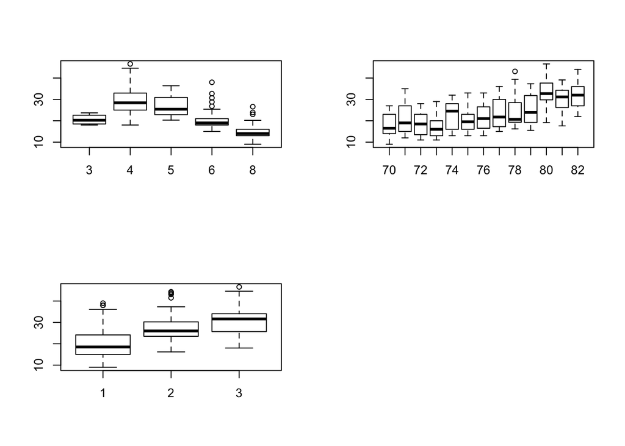

```r
par(mfrow=c(2,2))
plot(Auto$cylinders,Auto$mpg)
plot(Auto$year,Auto$mpg)
plot(Auto$origin,Auto$mpg)
```

The mpg as function of cylinder follows parabola. On average, a cylinder of 4 has the highest mpg. On average, higher mpg are associated with higher years. On average, higher mpg are associated with origin increasing order.

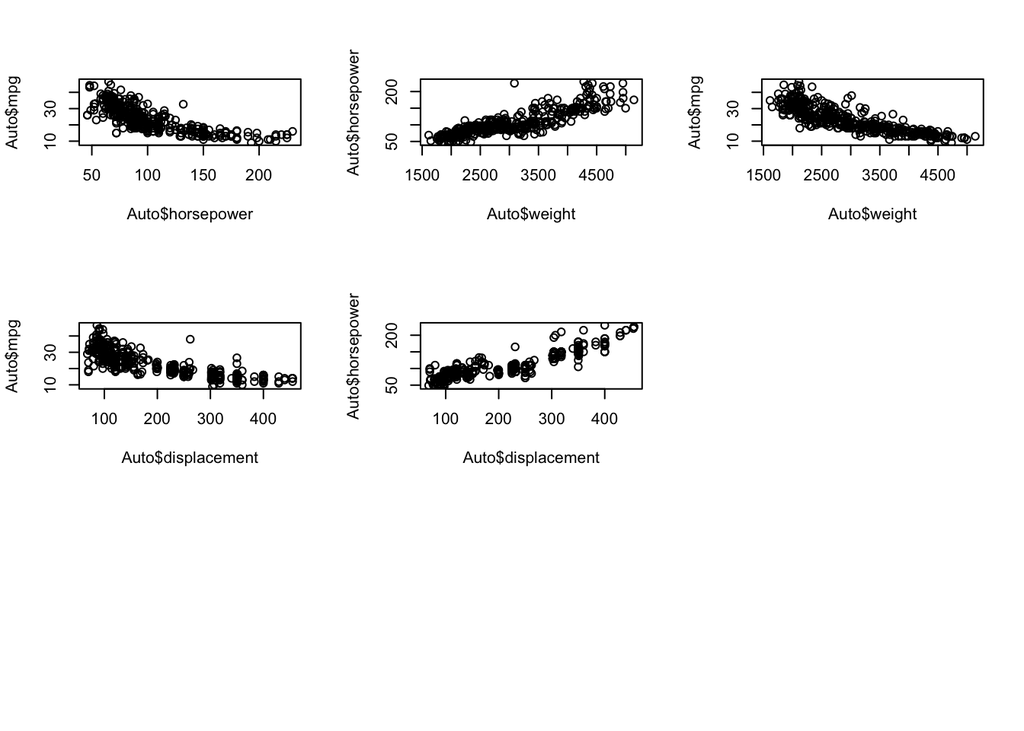

```r
par(mfrow=c(3,3))
plot(Auto$horsepower,Auto$mpg)
plot(Auto$weight,Auto$horsepower)
plot(Auto$weight,Auto$mpg)
plot(Auto$displacement,Auto$mpg)
plot(Auto$displacement,Auto$horsepower)
```

Mpg and horsepower are negatively correlated. Weight and horsepower are positively correlated. Weight and mpg are negatively correlated. Displacement and mpg are negatively correlated. Displacement and horsepower are positively correlated.

## 2.4.9 (f)

Yes, other variables could be used to predict mpg. Looking at the block and scatter plot of all the variables, you can see there is a strong between mpg and the variables.